# plant_seedlings_image_classification_project7

**Context**: Can you differentiate a weed from a crop seedling? The ability to do so effectively can mean better crop yields and better stewardship of the environment. The Aarhus University Signal Processing group, in collaboration with University of Southern Denmark, has recently released a dataset containing images of unique plants belonging to 12 species at several growth stages **Objective:** To implement the techniques learnt as a part of the course. Learning Outcomes:  Pre-processing of image data.  Visualization of images.  Building CNN.  Evaluate the Model.  The motive of the project is to make the learners capable to handle images/image classification problems, during this process you should also be capable to handle real image files, not just limited to a numpy array of image pixels. **Guide to solve the project seamlessly:** Here are the points which will help you to solve the problem efficiently:  Read the problem statement carefully from start to end (including the note at the end). The highlighted part in the attached problem statement should not be missed.  Download the dataset from the Olympus platform.  Upload the "images.npy" and “Labels.csv” file to google drive.  Then you can use the dataset path in the Google Colab notebook to do further steps related to project problem statement.  You can set runtime type to “GPU” in Google Colab, so that the code will run faster as you will be using CNN to fit your model. Steps and tasks:

1. Import the libraries, load dataset, print shape of data, visualize the images in dataset. (5 Marks)
2. Data Pre-processing: (15 Marks) a. Normalization. b. Gaussian Blurring. c. Visualize data after pre-processing.
3. Make data compatible: (10 Marks) a. Convert labels to one-hot-vectors. b. Print the label for y_train[0]. c. Split the dataset into training, testing, and validation set. (Hint: First split images and labels into training and testing set with test_size = 0.3. Then further split test data into test and validation set with test_size = 0.5) d. Check the shape of data, Reshape data into shapes compatible with Keras models if it’s not already. If it’s already in the compatible shape, then comment in the notebook that it’s already in compatible shape.
4. Building CNN: (15 Marks) a. Define layers. b. Set optimizer and loss function. (Use Adam optimizer and categorical crossentropy.)
5. Fit and evaluate model and print confusion matrix. (10 Marks)
6. Visualize predictions for x_test[2], x_test[3], x_test[33], x_test[36], x_test[59]. (5 Marks)

**Import the libraries, load dataset, print shape of data, visualize the images in dataset.**

```python
# Import the libraries

import cv2
import numpy as np
import pandas as pd
import tensorflow as tf
import matplotlib.pyplot as plt
%matplotlib inline

from tensorflow.keras import datasets, models, layers, optimizers
from tensorflow.keras.preprocessing.image import ImageDataGenerator
from tensorflow.keras.callbacks import ModelCheckpoint, EarlyStopping
from google.colab.patches import cv2_imshow
import matplotlib.image as mpimg

import warnings
# Suppress warnings
warnings.filterwarnings('ignore')
```

```python
from google.colab import drive
```

```python
drive.mount('/content/drive/')
```

```python
project_path = '/content/drive/My Drive/Colab Notebooks/'
```

```python
dataset_file = project_path + 'Labels.csv'
img_file=project_path + 'images.npy'
```

```python
# load the dataset
df_labels = pd.read_csv(dataset_file)
img=np.load(img_file)
```

```python
df_labels['Label'].unique()
```

```
array(['Small-flowered Cranesbill', 'Fat Hen', 'Shepherds Purse',
       'Common wheat', 'Common Chickweed', 'Charlock', 'Cleavers',
       'Scentless Mayweed', 'Sugar beet', 'Maize', 'Black-grass',
       'Loose Silky-bent'], dtype=object)
```

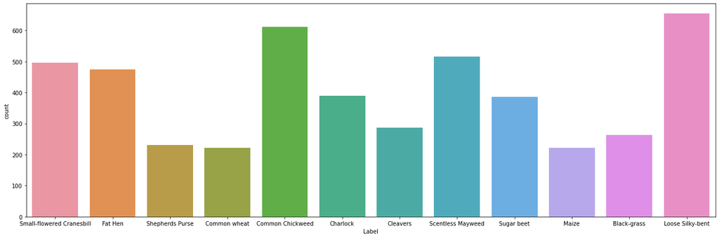

```python
import seaborn as sns
fig, ax = plt.subplots(figsize=(22,7))
sns.countplot(df_labels['Label'])
```

```python
# print shape of data
df_labels.shape
```

```
(4750, 1)
```

```python
img.shape
```

```
(4750, 128, 128, 3)
```

**Insights:**

1. There are total 4750 images.
2. Size of each image is 128x128 pixels.
3. Each image has three color channels.

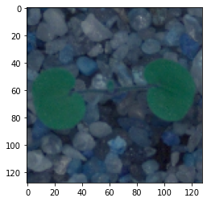

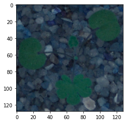

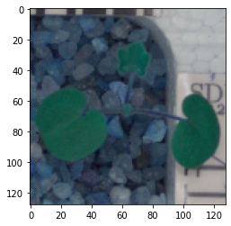

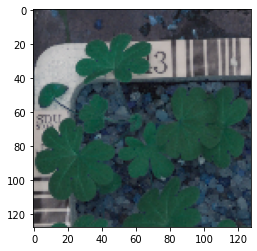

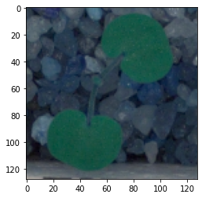

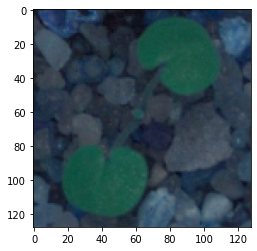

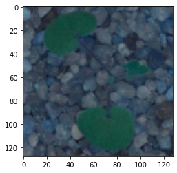

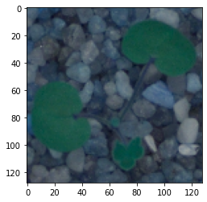

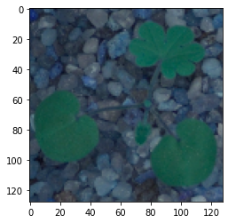

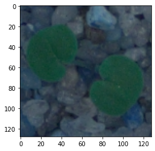

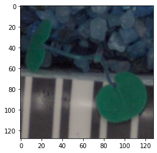

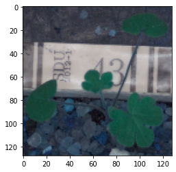

```python
#visualize the images in dataset
for i in range(0, 12):
   plt.figure()
   plt.imshow(img[i])
```

*Data Pre-processing:*

**a. Normalization** When using Neural Networks, Normalization helps. (Neural networks process inputs using small weight values, and inputs with large integer values can disrupt or slow down the learning process.) As such it is good practice to normalize the pixel values so that each pixel value has a value between 0 and 1.

```python
img[0].shape
```

```
(128, 128, 3)
```

```python
img = img.astype('float32')
#img = img.astype('float32')
img /= 255.0
```

**b. Gaussian Blurring**

```python
blur1 = cv2.GaussianBlur(img[10],(5,5),0)
blur2 = cv2.GaussianBlur(img[10], (15, 15), 0)
```

**c. Visualize data after pre-processing**

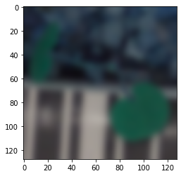

```python
plt.imshow(blur2)
```

```python
img.shape
```

```
(4750, 128, 128, 3)
```

**Make data compatible:** a. Convert labels to one-hot-vectors. b. Print the label for y_train[0]. c. Split the dataset into training, testing, and validation set. (Hint: First split images and labels into training and testing set with test_size = 0.3. Then further split test data into test and validation set with test_size = 0.5) d. Check the shape of data, Reshape data into shapes compatible with Keras models if it’s not already. If it’s already in the compatible shape, then comment in the notebook that it’s already in compatible shape.

**a. Convert labels to one-hot-vectors.**

```python
# creating initial dataframe
label_name = ('Small-flowered Cranesbill', 'Fat Hen', 'Shepherds Purse',
       'Common wheat', 'Common Chickweed', 'Charlock', 'Cleavers',
       'Scentless Mayweed', 'Sugar beet', 'Maize', 'Black-grass',
       'Loose Silky-bent')
label_df = pd.DataFrame(label_name, columns=['label_name'])
# converting type of columns to 'category'
label_df['label_name'] = label_df['label_name'].astype('category')
# Assigning numerical values and storing in another column
label_df['label'] = label_df['label_name'].cat.codes
label_df
```

|  | label_name | label |
| --- | --- | --- |
| 0 | Small-flowered Cranesbill | 10 |
| 1 | Fat Hen | 5 |
| 2 | Shepherds Purse | 9 |
| 3 | Common wheat | 4 |
| 4 | Common Chickweed | 3 |
| 5 | Charlock | 1 |
| 6 | Cleavers | 2 |
| 7 | Scentless Mayweed | 8 |
| 8 | Sugar beet | 11 |
| 9 | Maize | 7 |
| 10 | Black-grass | 0 |
| 11 | Loose Silky-bent | 6 |

```python
from sklearn.preprocessing import LabelEncoder
#creating instance of labelencoder
labelencoder = LabelEncoder()
df_labels = labelencoder.fit_transform(df_labels)
df_labels
```

```
array([10, 10, 10, ...,  6,  6,  6])
```

```python
 #Convert labels to one hot vectors.

from sklearn.preprocessing import LabelBinarizer
enc = LabelBinarizer()
labels= enc.fit_transform(df_labels)
labels
```

```
array([[0, 0, 0, ..., 0, 1, 0],
       [0, 0, 0, ..., 0, 1, 0],
       [0, 0, 0, ..., 0, 1, 0],
       ...,
       [0, 0, 0, ..., 0, 0, 0],
       [0, 0, 0, ..., 0, 0, 0],
       [0, 0, 0, ..., 0, 0, 0]])
```

```python
labels.shape
```

```
(4750, 12)
```

**b. Print the label for y_train[0].**

```python
y_train=labels
```

```python
y_train[0]
```

```
array([0, 0, 0, 0, 0, 0, 0, 0, 0, 0, 1, 0])
```

**c. Split the dataset into training, testing, and validation set.**

```python
from sklearn.model_selection import train_test_split
# Split the data up in train and test sets
X_train, X_test, Y_train, Y_test = train_test_split(img, labels, test_size=0.30, random_state=1)
```

```python
X_test, X_val, Y_test, Y_val = train_test_split(X_test, Y_test, test_size=0.50, random_state=1)
```

**d. Check the shape of data, Reshape data into shapes compatible with Keras models if it’s not already. If it’s already in the compatible shape, then comment in the notebook that it’s already in compatible shape.**

In Keras, the input layer itself is not a layer, but a tensor. It's the starting tensor you send to the first hidden layer. This tensor must have the same shape as our training data. Example: if you have 30 images of 50x50 pixels in RGB (3 channels), the shape of your input data is (30,50,50,3) .

```python
print(X_train.shape)
print(X_test.shape)
print(X_val.shape)
print(Y_train.shape)
print(Y_test.shape)
print(Y_val.shape)
```

```
(3325, 128, 128, 3)
(712, 128, 128, 3)
(713, 128, 128, 3)
(3325, 12)
(712, 12)
(713, 12)
```

Sequential model in tensorflow.keras expects data to be in the format (n_e, n_h, n_w, n_c)

n_e= number of examples, n_h = height, n_w = width, n_c = number of channels

No need to reshape labels.

Why might we want to utilize different image dimensions?

There are two common reasons:

our input image dimensions are considerably smaller than what the CNN was trained on and increasing their size introduces too many artifacts and dramatically hurts loss/accuracy. our images are high resolution and contain small objects that are hard to detect. Resizing to the original input dimensions of the CNN hurts accuracy and you postulate increasing resolution will help improve your model.

In these scenarios, it’s already in the compatible shape, and able to perform transfer learning.

**Building CNN: (15 Marks) a. Define layers. b. Set optimizer and loss function. (Use Adam optimizer and categorical crossentropy.)**

```python
from tensorflow.keras.models import Sequential          # Sequential groups a linear stack of layers into a tf.keras.Model.
from tensorflow.keras.layers import Conv2D              # This layer creates a convolution kernel that is convolved with the layer input to produce a tensor of outputs.
from tensorflow.keras.layers import MaxPooling2D        # Max pooling operation for 2D spatial data.
from tensorflow.keras.layers import Flatten             # Flattens the input. Does not affect the batch size.
from tensorflow.keras.layers import Dense, Dropout      # Dropout: Applies Dropout to the input.
                                                        # Dense: Just your regular densely-connected NN layer
model = models.Sequential()
model.add(layers.Conv2D(32, (5, 5), padding='same', activation="relu", input_shape=X_train.shape[1:]))
model.add(Conv2D(filters = 32, kernel_size = (5,5),padding = 'Same', activation ='relu'))
#model.add(layers.BatchNormalization())
model.add(layers.MaxPooling2D((2, 2)))
model.add(layers.Dropout(0.2))
model.add(layers.Conv2D(64, (5, 5), padding='same', activation="relu"))
model.add(Conv2D(filters = 64, kernel_size = (3,3),padding = 'same', activation ='relu'))
#model.add(layers.BatchNormalization())
model.add(layers.MaxPooling2D((2, 2)))
model.add(layers.Dropout(0.3))
model.add(layers.Conv2D(128, (3, 3), padding='same', activation="relu"))
model.add(layers.Conv2D(128, (3, 3), padding='same', activation="relu"))
#model.add(layers.BatchNormalization())
model.add(layers.MaxPooling2D((2, 2)))
model.add(layers.Dropout(0.4))
#model.add(layers.Conv2D(64, (3, 3), padding='same', activation="relu"))
#model.add(layers.BatchNormalization())
#model.add(layers.MaxPooling2D((2, 2)))
#model.add(layers.Dropout(0.5))

model.add(layers.GlobalMaxPooling2D())
model.add(layers.Dense(256, activation="relu"))
model.add(layers.Dropout(0.5))
model.add(layers.Dense(12, activation="softmax"))

model.summary()
```

```
Model: "sequential_1"
_________________________________________________________________
Layer (type)                 Output Shape              Param #
=================================================================
conv2d_6 (Conv2D)            (None, 128, 128, 32)      2432
_________________________________________________________________
conv2d_7 (Conv2D)            (None, 128, 128, 32)      25632
_________________________________________________________________
max_pooling2d_3 (MaxPooling2 (None, 64, 64, 32)        0
_________________________________________________________________
dropout_4 (Dropout)          (None, 64, 64, 32)        0
_________________________________________________________________
conv2d_8 (Conv2D)            (None, 64, 64, 64)        51264
_________________________________________________________________
conv2d_9 (Conv2D)            (None, 64, 64, 64)        36928
_________________________________________________________________
max_pooling2d_4 (MaxPooling2 (None, 32, 32, 64)        0
_________________________________________________________________
dropout_5 (Dropout)          (None, 32, 32, 64)        0
_________________________________________________________________
conv2d_10 (Conv2D)           (None, 32, 32, 128)       73856
_________________________________________________________________
conv2d_11 (Conv2D)           (None, 32, 32, 128)       147584
_________________________________________________________________
max_pooling2d_5 (MaxPooling2 (None, 16, 16, 128)       0
_________________________________________________________________
dropout_6 (Dropout)          (None, 16, 16, 128)       0
_________________________________________________________________
global_max_pooling2d_1 (Glob (None, 128)               0
_________________________________________________________________
dense_2 (Dense)              (None, 256)               33024
_________________________________________________________________
dropout_7 (Dropout)          (None, 256)               0
_________________________________________________________________
dense_3 (Dense)              (None, 12)                3084
=================================================================
Total params: 373,804
Trainable params: 373,804
Non-trainable params: 0
_________________________________________________________________
```

```python
# initiate Adam optimizer
opt = optimizers.Adam(learning_rate=0.001, beta_1=0.9, beta_2=0.999, epsilon=1e-08)
model.compile(optimizer = opt, loss = 'categorical_crossentropy', metrics = ['accuracy'])
```

**Fit and evaluate model and print confusion matrix.**

```python
batch_size = 35
model.fit(X_train, Y_train, epochs = 50, validation_data = (X_val,Y_val),batch_size = batch_size)

#Adding Early stopping callback to the fit function is going to stop the training,
#if the val_loss is not going to change even '0.001' for more than 10 continous epochs
from tensorflow.keras.callbacks import ModelCheckpoint, EarlyStopping

early_stopping = EarlyStopping(monitor='val_loss', min_delta=0.001, patience=10)

#Adding Model Checkpoint callback to the fit function is going to save the weights whenever val_loss achieves a new low value.
#Hence saving the best weights occurred during training

model_checkpoint =  ModelCheckpoint('cifar_cnn_checkpoint_{epoch:02d}_loss{val_loss:.4f}.h5',
                                                           monitor='val_loss',
                                                           verbose=1,
                                                           save_best_only=True,
                                                           save_weights_only=True,
                                                           mode='auto',
                                                           period=1)
```

```
WARNING:tensorflow:`period` argument is deprecated. Please use `save_freq` to specify the frequency in number of batches seen.
```

```python
results = model.evaluate(X_test, Y_test)
```

```python
print(model.metrics_names)
print(results)
```

```
['loss', 'accuracy']
[0.37199851870536804, 0.8707864880561829]
```

[output not shown]

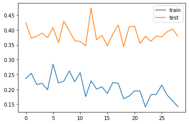

```python
history = model.fit(X_train,
                    Y_train,
                    batch_size=batch_size,
                    epochs=35,
                    validation_data=(X_test, Y_test),
                    shuffle=True,
                    verbose=1,
                    callbacks=[early_stopping,model_checkpoint])
# plot training history
plt.plot(history.history['loss'], label='train')
plt.plot(history.history['val_loss'], label='test')
plt.legend()
plt.show()
```

```python
#prediction variable
Y_pred = model.predict(X_test)
```

```python
Y_pred=np.argmax(Y_pred, axis=1)
Y_test=np.argmax(Y_test, axis=1)
```

```python
from sklearn.metrics import accuracy_score, confusion_matrix, precision_score, recall_score, f1_score, precision_recall_curve, auc
CM=confusion_matrix(Y_test, Y_pred)
CM
```

```
array([[23,  0,  0,  0,  4,  0, 23,  0,  0,  0,  0,  1],
       [ 0, 45,  2,  0,  0,  1,  0,  0,  0,  1,  0,  0],
       [ 0,  5, 38,  1,  0,  0,  0,  0,  2,  0,  1,  0],
       [ 0,  0,  0, 79,  0,  0,  0,  0,  4,  2,  1,  0],
       [ 1,  0,  0,  0, 24,  4,  0,  0,  0,  0,  0,  0],
       [ 0,  1,  0,  1,  0, 71,  0,  0,  1,  0,  0,  0],
       [ 6,  0,  0,  0,  0,  2, 93,  0,  0,  0,  0,  0],
       [ 0,  0,  0,  0,  1,  0,  1, 30,  1,  0,  0,  2],
       [ 0,  0,  1,  0,  0,  0,  0,  0, 66,  0,  0,  0],
       [ 0,  0,  0,  0,  0,  0,  0,  0,  7, 34,  0,  0],
       [ 0,  2,  0,  0,  0,  0,  0,  0,  1,  1, 70,  0],
       [ 0,  1,  0,  0,  0,  1,  0,  0,  2,  0,  0, 54]])
```

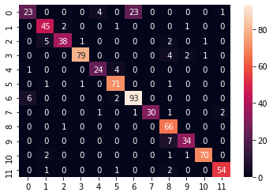

```python
import seaborn as sns
sns.heatmap(CM,fmt='2', annot=True)
```

```python
from sklearn.metrics import classification_report
cr=classification_report(Y_test,Y_pred)
print(cr)
```

```
              precision    recall  f1-score   support

           0       0.77      0.45      0.57        51
           1       0.83      0.92      0.87        49
           2       0.93      0.81      0.86        47
           3       0.98      0.92      0.95        86
           4       0.83      0.83      0.83        29
           5       0.90      0.96      0.93        74
           6       0.79      0.92      0.85       101
           7       1.00      0.86      0.92        35
           8       0.79      0.99      0.87        67
           9       0.89      0.83      0.86        41
          10       0.97      0.95      0.96        74
          11       0.95      0.93      0.94        58

    accuracy                           0.88       712
   macro avg       0.89      0.86      0.87       712
weighted avg       0.88      0.88      0.88       712
```

**Visualize predictions for x_test[2], x_test[3], x_test[33], x_test[36], x_test[59]**

```
Actual label: 3
```

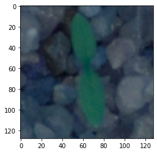

```python
print("Actual label:", Y_test[2])
plt.imshow(X_test[2])
```

```
Predicted label: 8
Softmax Outputs: [[4.75942159e-07 3.94051904e-06 2.67539959e-04 2.55342096e-01
  1.08719605e-05 6.94002447e-05 4.48762876e-05 1.58162758e-04
  4.09259290e-01 2.09305406e-01 1.86573525e-05 1.25519246e-01]]
0.9999999
```

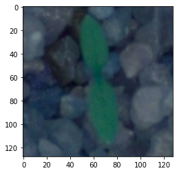

```python
import matplotlib.pyplot as plt
%matplotlib inline

plt.imshow(X_test[2].reshape(128, 128,3), cmap='gray')
Y_pred = model.predict(X_test[2].reshape(1, 128, 128, 3))
print("Predicted label:", Y_pred.argmax())
print("Softmax Outputs:", Y_pred)
print(Y_pred.sum())
```

```
Actual label: 0
```

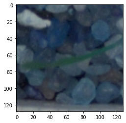

```python
print("Actual label:", Y_test[3])
plt.imshow(X_test[3])
```

```
Predicted label: 0
Softmax Outputs: [[8.7227511e-01 2.6479379e-15 1.6894629e-10 1.3607976e-07 3.5342153e-03
  1.0711146e-07 1.2404370e-01 3.7973149e-09 1.9760696e-08 9.2682285e-12
  1.4672292e-04 8.2159786e-11]]
1.0
```

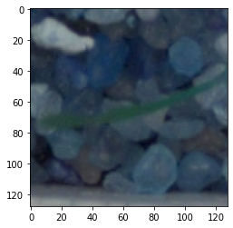

```python
plt.imshow(X_test[3].reshape(128, 128,3), cmap='gray')
Y_pred = model.predict(X_test[3].reshape(1, 128, 128, 3))
print("Predicted label:", Y_pred.argmax())
print("Softmax Outputs:", Y_pred)
print(Y_pred.sum())
```

```
Actual label: 6
```

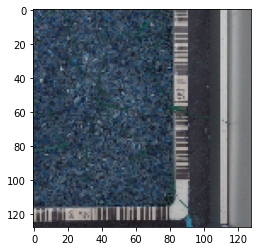

```python
print("Actual label:", Y_test[33])
plt.imshow(X_test[33])
```

```
Predicted label: 6
Softmax Outputs: [[4.1681075e-01 6.2306810e-08 4.5727711e-06 9.0049952e-04 9.3548454e-04
  4.3656459e-04 5.8047301e-01 7.6712613e-06 2.6378644e-04 1.5938463e-06
  1.5598838e-04 1.0041344e-05]]
1.0
```

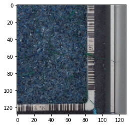

```python
plt.imshow(X_test[33].reshape(128, 128,3), cmap='gray')
Y_pred = model.predict(X_test[33].reshape(1, 128, 128, 3))
print("Predicted label:", Y_pred.argmax())
print("Softmax Outputs:", Y_pred)
print(Y_pred.sum())
```

```
Actual label: 3
```

[figure not shown]

```python
print("Actual label:", Y_test[36])
plt.imshow(X_test[36])
```

```
Predicted label: 3
Softmax Outputs: [[3.85135093e-13 1.09983966e-09 1.58876823e-08 9.93278205e-01
  3.74276288e-15 1.18084805e-04 1.93328450e-10 7.68257920e-08
  1.37704817e-04 4.42325929e-03 2.03936920e-03 3.26819600e-06]]
0.99999994
```

[figure not shown]

```python
plt.imshow(X_test[36].reshape(128, 128,3), cmap='gray')
Y_pred = model.predict(X_test[36].reshape(1, 128, 128, 3))
print("Predicted label:", Y_pred.argmax())
print("Softmax Outputs:", Y_pred)
print(Y_pred.sum())
```

```
Actual label: 10
```

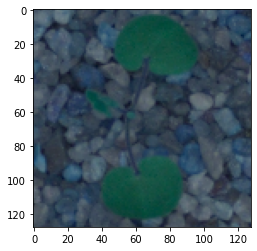

```python
print("Actual label:", Y_test[59])
plt.imshow(X_test[59])
```

```
Predicted label: 10
Softmax Outputs: [[5.9142967e-18 1.2121473e-09 2.5698787e-08 8.4441673e-08 3.9896896e-21
  8.1745810e-09 2.7180257e-20 2.7854936e-08 2.2760720e-10 3.3294498e-10
  9.9999988e-01 7.7432544e-10]]
1.0
```

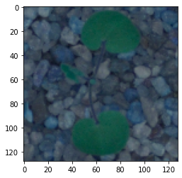

```python
plt.imshow(X_test[59].reshape(128, 128,3), cmap='gray')
Y_pred = model.predict(X_test[59].reshape(1, 128, 128, 3))
print("Predicted label:", Y_pred.argmax())
print("Softmax Outputs:", Y_pred)
print(Y_pred.sum())
```